# Esercizi 2

# esercizi di laboratorio su dataset

## Compito del 1 febbraio 2017

Let us consider the dataframe mtcars, which comprises the fuel consumption and 10 aspects of design and performance for 32 automobiles (1970s models). The help file is given below

| mtcars | R Documentation |
| --- | --- |

## Motor Trend Car Road Tests

### Format

A data frame with 32 observations on 11 (numeric) variables.

| [, 1] | mpg | Miles/(US) gallon |
| --- | --- | --- |
| [, 2] | cyl | Number of cylinders |
| [, 3] | disp | Displacement (cu.in.) |
| [, 4] | hp | Gross horsepower |
| [, 5] | drat | Rear axle ratio |
| [, 6] | wt | Weight (1000 lbs) |
| [, 7] | qsec | 1/4 mile time |
| [, 8] | vs | Engine (0 = V-shaped, 1 = straight) |
| [, 9] | am | Transmission (0 = automatic, 1 = manual) |
| [,10] | gear | Number of forward gears |
| [,11] | carb | Number of carburetors |

Describe how to perform a preliminary data analysis on this dataframe, using suitable R commands.

```r
newMtcars <- mtcars
newMtcars$vs <- factor(mtcars$vs, labels = c("V-shaped", "straight"))
newMtcars$am <- factor(mtcars$am, labels = c("automatic", "manual"))
```

Il dataset contiene una serie di dati su diversi modelli di automobili, tra cui i consumi di carburante (per miglio) e una serie di aspetti tecnici legati al design e alle performance dell’auto. Diamo un’occhiata alle variabili:

```r
summary(newMtcars)
```

|  | mpg | cyl | disp | hp | drat | wt | qsec | vs | am | gear | carb |
| --- | --- | --- | --- | --- | --- | --- | --- | --- | --- | --- | --- |
|  | Min. :10.40 | Min. :4.000 | Min. : 71.1 | Min. : 52.0 | Min. :2.760 | Min. :1.513 | Min. :14.50 | V-shaped:18 | automatic:19 | Min. :3.000 | Min. :1.000 |
|  | 1st Qu.:15.43 | 1st Qu.:4.000 | 1st Qu.:120.8 | 1st Qu.: 96.5 | 1st Qu.:3.080 | 1st Qu.:2.581 | 1st Qu.:16.89 | straight:14 | manual :13 | 1st Qu.:3.000 | 1st Qu.:2.000 |
|  | Median :19.20 | Median :6.000 | Median :196.3 | Median :123.0 | Median :3.695 | Median :3.325 | Median :17.71 | NA | NA | Median :4.000 | Median :2.000 |
|  | Mean :20.09 | Mean :6.188 | Mean :230.7 | Mean :146.7 | Mean :3.597 | Mean :3.217 | Mean :17.85 | NA | NA | Mean :3.688 | Mean :2.812 |
|  | 3rd Qu.:22.80 | 3rd Qu.:8.000 | 3rd Qu.:326.0 | 3rd Qu.:180.0 | 3rd Qu.:3.920 | 3rd Qu.:3.610 | 3rd Qu.:18.90 | NA | NA | 3rd Qu.:4.000 | 3rd Qu.:4.000 |
|  | Max. :33.90 | Max. :8.000 | Max. :472.0 | Max. :335.0 | Max. :4.930 | Max. :5.424 | Max. :22.90 | NA | NA | Max. :5.000 | Max. :8.000 |

Osservazioni:

- sono presenti 9 variabili numeriche e 2 categoriali,
- le variabili categoriali (vs e am) sono di tipo nominale,
- mpg, disp, hp, drat, wt e qsec sono di tipo continuo,
- cyl, gear e carb sono di tipo discreto (valori interi),

mpg rappresenta i consumi del modello in miglia percorsi con un gallone di carburante. Per il significato delle altre variabili si suggerisce di consultare l’help.

Supponendo che la nostra analisi sia focalizzata sullo studio dei consumi dei veicoli. Ora ci si concentra sulle caratteristiche della variabile mpg.

Si parte da una panoramica sulla distribuzione di frequenza e dei quantili

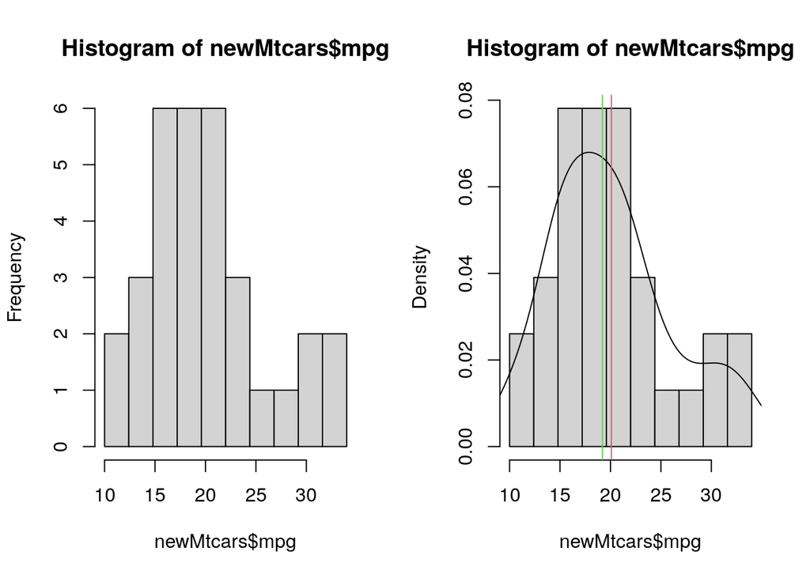

```r
par(mfrow = c(1,2))
hist(newMtcars$mpg, breaks = 10 + (0:10) * 2.4)
hist(newMtcars$mpg, breaks = 10 + (0:10) * 2.4, probability = T)
lines(density(newMtcars$mpg))
abline(v=mean(newMtcars$mpg), col=2)
abline(v=median(newMtcars$mpg), col=3)
```

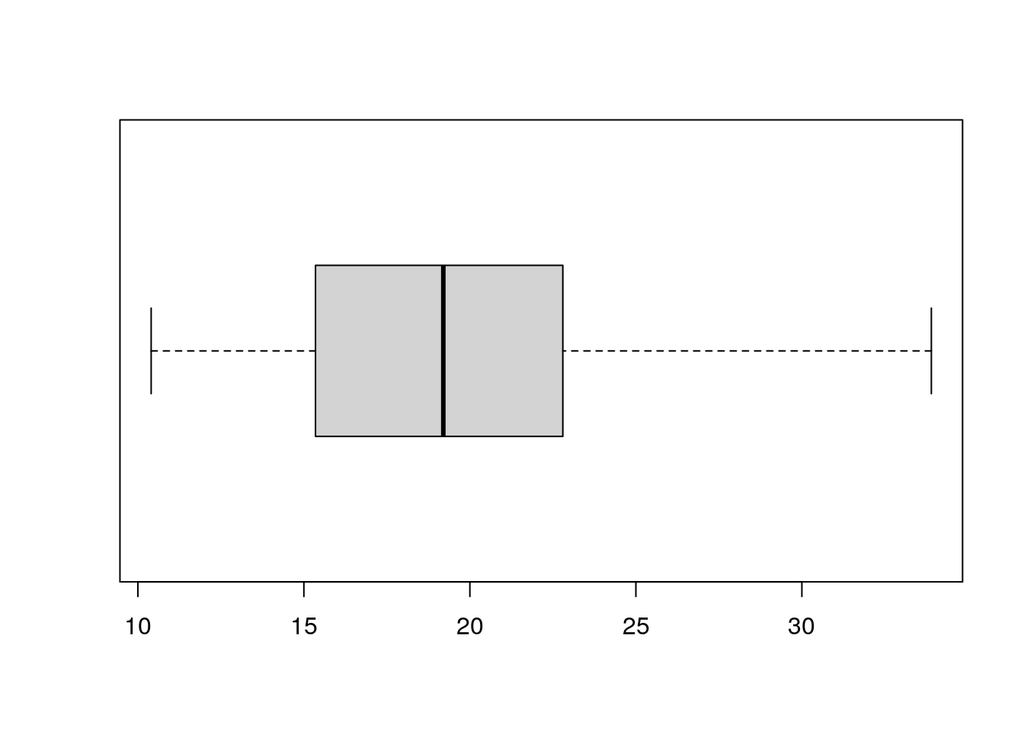

```r
par(mfrow = c(1,1))
boxplot(newMtcars$mpg, horizontal = T)
```

Osservazioni:

- la densità presenta un andamento simil-normale, con un picco inferiore sia alla media che alla mediana, e un massimo locale sulla coda destra, appesantendola di conseguenza,
- sia dagli istogrammi che dal boxplot si osserva una asimmetria,
- non si nota la presenza di particolari outlier,
- nonostante tutto, la media non è molto distante dalla mediana.

```r
library(moments)
skewness(newMtcars$mpg)
```

```
## [1] 0.6404399
```

```r
kurtosis(newMtcars$mpg)
```

```
## [1] 2.799467
```

Osservazioni:

- skewness abbastanza bassa, leggera asimmetria verso destra
- curtosi non troppo distante da 3, quindi la distribuzione è leggermente di tipo iponormale

Vista la particolare distribuzione dei dati si potrebbe considerare di partizionare il dataset in veicoli a basso consumo (mpg < 25) e ad alto consumo (mpg $\leq$ 25), oppure considerare una trasformata della variabile (es. logaritmo)

```r
logMtcarsMpg <- log(newMtcars$mpg)
summary(logMtcarsMpg)
```

| Min. | 1st Qu. | Median | Mean | 3rd Qu. | Max. |
| --- | --- | --- | --- | --- | --- |
| 2.341806 | 2.735954 | 2.95491 | 2.957514 | 3.126761 | 3.523415 |

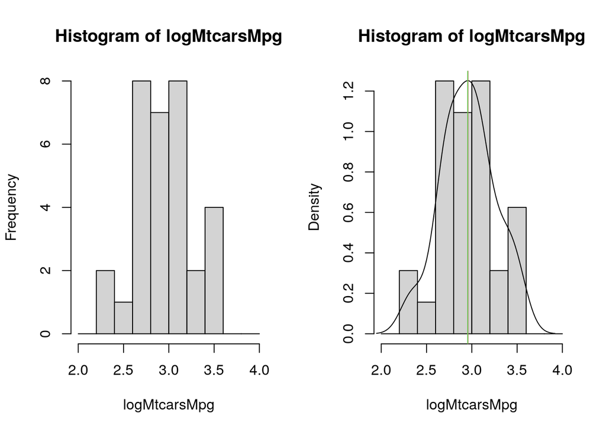

```r
breaks <- 2 + (0:10) * 0.2
par(mfrow = c(1,2))
hist(logMtcarsMpg, breaks = breaks)
hist(logMtcarsMpg, probability = T, breaks = breaks)
lines(density(logMtcarsMpg))
abline(v=mean(logMtcarsMpg), col=2)
abline(v=median(logMtcarsMpg), col=3)
```

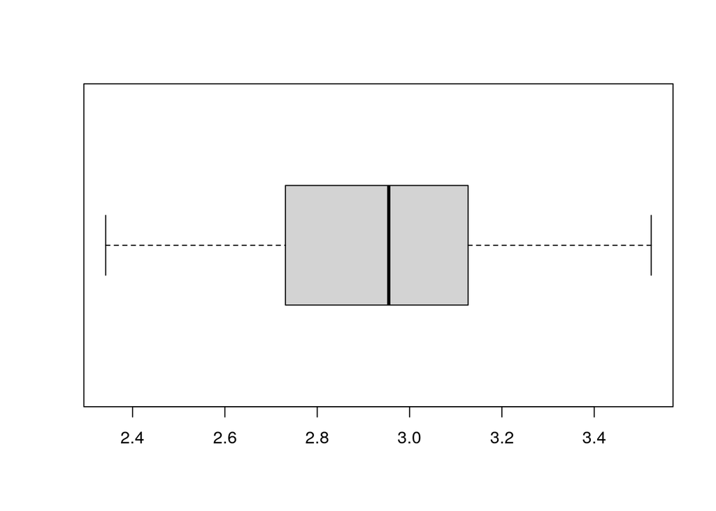

```r
par(mfrow = c(1,1))
boxplot(logMtcarsMpg, horizontal = T)
```

```r
skewness(logMtcarsMpg)
```

```
## [1] -0.02241292
```

```r
kurtosis(logMtcarsMpg)
```

```
## [1] 2.64908
```

Osservazioni:

- con il logaritmo si ottiene una maggiore simmetria del grafico, a scapito di una leggera diminuzione dell’indice di curtosi

Proviamo a ricercare delle ipotetiche correlazioni tra mpg e le altre variabili:

### Variabili continue

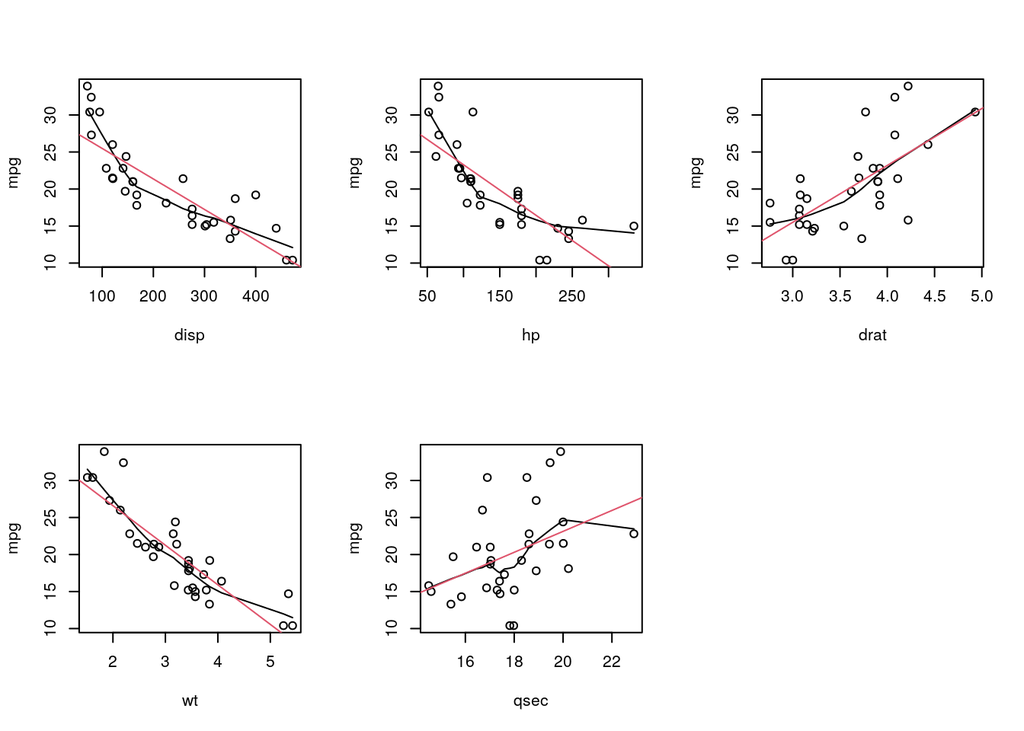

```r
par(mfrow=c(2,3))
for (i in c("disp", "hp", "drat", "wt", "qsec")) {
  plot(newMtcars[, i], newMtcars$mpg, xlab = i, ylab = "mpg")
  lines(lowess(newMtcars[, i], newMtcars$mpg), col=1)
  abline(lm(newMtcars$mpg~newMtcars[, i]), col=2)
}
par(mfrow=c(1,1))
```

### Variabili discrete

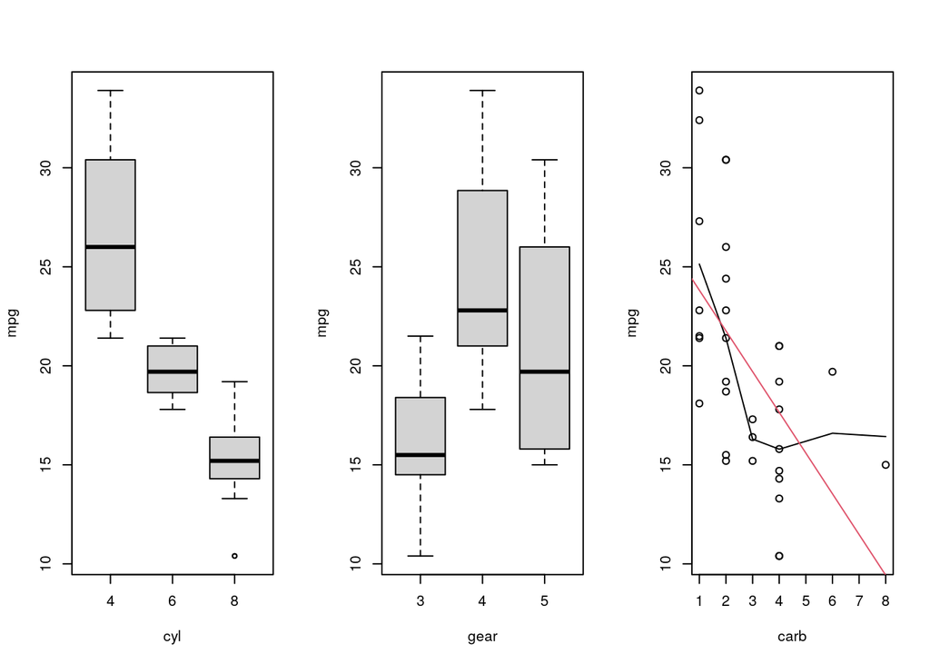

```r
par(mfrow = c(1,3))
boxplot(mpg~cyl, data = newMtcars)
boxplot(mpg~gear, data = newMtcars)
plot(mpg~carb, data = newMtcars)
lines(lowess(newMtcars$carb, newMtcars$mpg), col=1)
abline(lm(mpg~carb, data = newMtcars), col=2)
```

```r
par(mfrow = c(1,1))
```

### Variabili categoriali

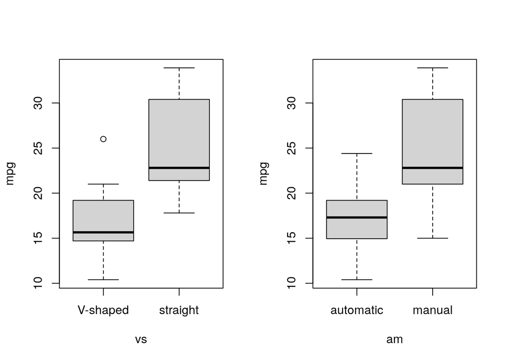

```r
par(mfrow=c(1,2))
boxplot(mpg~vs, data = newMtcars)
boxplot(mpg~am, data = newMtcars)
```

```r
par(mfrow=c(1,1))
```

Dai grafici si può ipotizzare che:

- le variabili vs, arm e cyl sembrano avere una forte influenza su mpg
- per quanto riguarda qsec e drat la correlazione sembra essere presente ma è molto leggera
- per quanto riguarda wt, disp e hp sembra esserci una correlazione, ma non è detto che sia di tipo lineare.

```r
cor(x = newMtcars$wt, y = newMtcars$mpg, method = "pearson")
```

```
## [1] -0.8676594
```

```r
cor(x = newMtcars$disp, y = newMtcars$mpg, method = "pearson")
```

```
## [1] -0.8475514
```

```r
cor(x = newMtcars$hp, y = newMtcars$mpg, method = "pearson")
```

```
## [1] -0.7761684
```

```r
cor(x = newMtcars$hp, y = newMtcars$mpg, method = "spearman")
```

```
## [1] -0.8946646
```

Gli indici di correlazione di pearson confermano la presenza di correlazioni lineari negative (discrete) per wt e disp. Per quanto riguarda hp, la relazione lineare c’è ma è meno significativa, tuttavia il coefficiente di spearman conferma l’esistenza di una correlazione.

A seguito di quanto visto anche dai grafici, proviamo a considerare una trasformazione di hp per cercare una correlazione migliore.

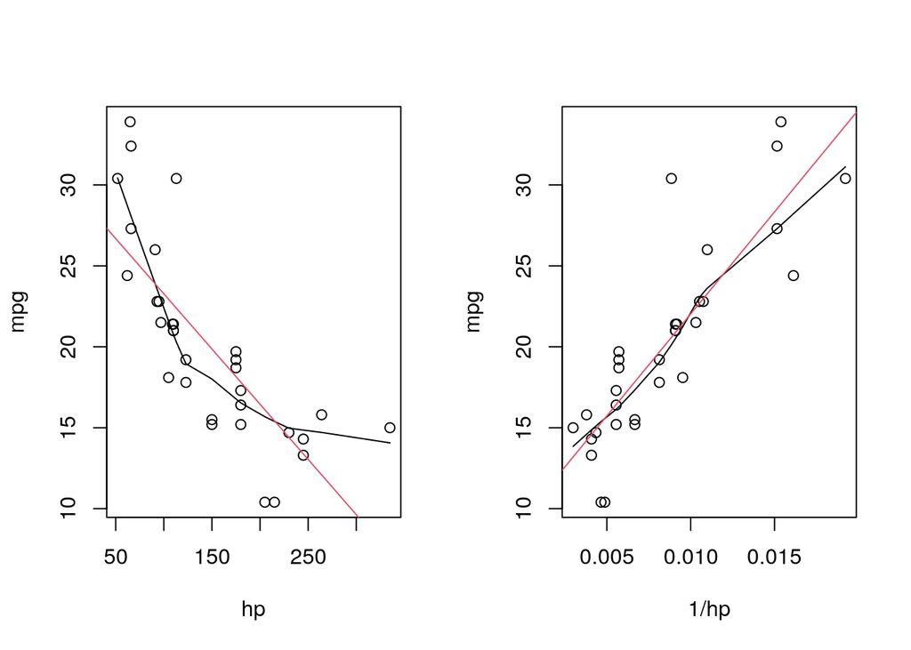

```r
par(mfrow=(c(1,2)))
plot(newMtcars$hp, newMtcars$mpg, xlab = "hp", ylab = "mpg")
lines(lowess(newMtcars$hp, newMtcars$mpg), col=1)
abline(lm(newMtcars$mpg~newMtcars$hp), col=2)

plot(1/newMtcars$hp, newMtcars$mpg, xlab = "1/hp", ylab = "mpg")
lines(lowess(1/newMtcars$hp, newMtcars$mpg), col=1)
abline(lm(newMtcars$mpg~I(1/newMtcars$hp)), col=2)
```

```r
par(mfrow=(c(1,1)))
```

Sembra esserci una buona correlazione lineare tra mpg e il reciproco di hp.

```r
cor(x = newMtcars$mpg, y = 1/newMtcars$hp, method = "pearson")
```

```
## [1] 0.8591321
```

After fitting the model `fit <- lm(mpg ∼ disp + hp + wt + drat, data=mtcars)`, the following outputs are obtained by the R commands `summary(fit)` and `plot(fit)`, respectively. Describe how to interpret these results, and then suggest how to proceed with further analyses.

```
##
## Call:
## lm(formula = mpg ~ disp + hp + wt + drat, data = mtcars)
##
## Residuals:
##     Min      1Q  Median      3Q     Max
## -3.5077 -1.9052 -0.5057  0.9821  5.6883
##
## Coefficients:
##              Estimate Std. Error t value Pr(>|t|)
## (Intercept) 29.148738   6.293588   4.631  8.2e-05 ***
## disp         0.003815   0.010805   0.353  0.72675
## hp          -0.034784   0.011597  -2.999  0.00576 **
## wt          -3.479668   1.078371  -3.227  0.00327 **
## drat         1.768049   1.319779   1.340  0.19153
## ---
## Signif. codes:  0 '***' 0.001 '**' 0.01 '*' 0.05 '.' 0.1 ' ' 1
##
## Residual standard error: 2.602 on 27 degrees of freedom
## Multiple R-squared:  0.8376, Adjusted R-squared:  0.8136
## F-statistic: 34.82 on 4 and 27 DF,  p-value: 2.704e-10
```

### Osservazioni

- Modello su quattro regressori continui
- si nota l’intercetta molto elevata e ha il p-value più basso
- il regressore disp ha un p-value elevato (ca. 72%), quindi la sua influenza sul risultato è ininfluente
- analogo discorso vale per drat (p-value ca. 19%)
- hp e wt risultano essere i regressori più influenti all’interno del modello, entrambi negativi e con p-value abbastanza bassi da tenerli nel modello.
- si osserva che i coefficienti di wt, drat e l’intercetta sono molto più elevati rispetto agli altri coefficienti. potrebbe indicare la necessità di normalizzare i dati per gestire meglio la diversità delle scale di ciascuna variabile
- dagli indici $R^2$ concludiamo che copriamo abbastanza bene la variabilità della variabile risposta con il modello
- il risultato del test F conferma quanto detto in precedenza

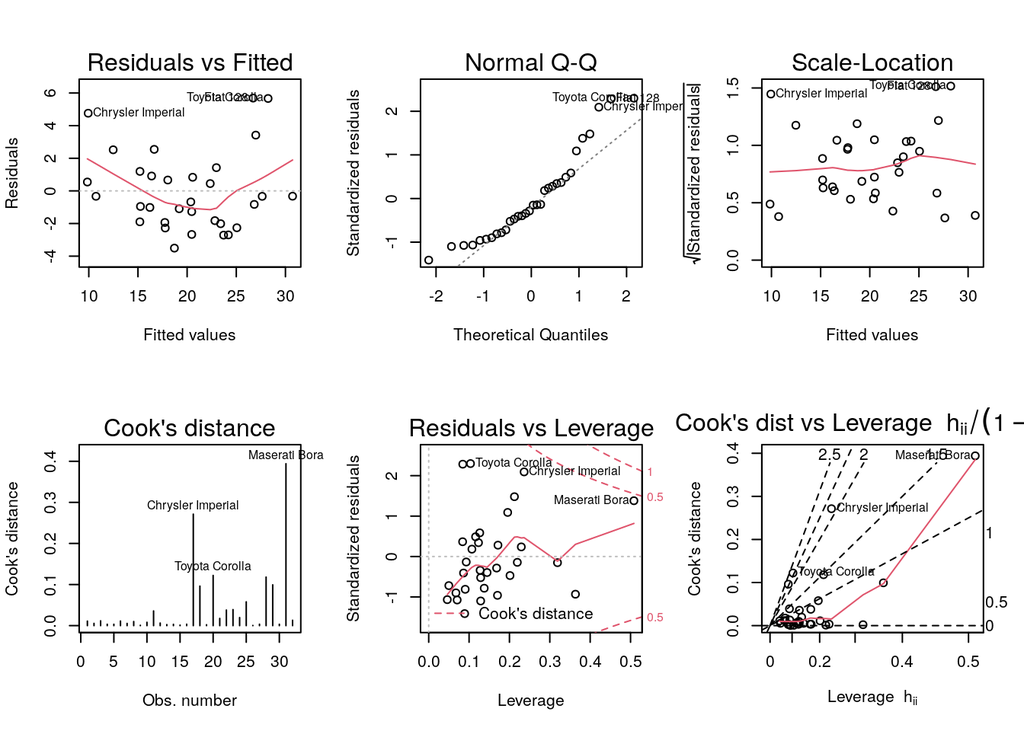

```r
par(mfrow = c(2,3))
plot(fit, which = c(1:6))
```

```r
par(mfrow=c(1,1))
```

Oss.

- Dal primo grafico, si osserva che la varianza dei residui non è costante. In particolare, per alcuni valori estremi si riscontrano residui significativi (che risultano tali anche quando standardizzati)
- Il secondo grafico evidenzia che i residui standardizzati si discostano significativamente dai quantili teorici per i valori non centrali.
- Dal quinto grafico si osserva un effetto leva non necessariamente corrispondente ad un alto residuo. Le distanze di cook sono contenute, quindi si può affermare che nessun punto è particolarmente influente (ci sono un paio di punti vicini alla soglia del 0.5). Il grafico delle distanza di Cook sostanzialmente conferma questa supposizione, evidenziando i tre valori critici.

Da tali diagnostiche, assieme a quanto emerso dal primo grafico, si osserva che sarebbe appropriato valutare modelli più complessi, magari che escludano i predittori che ottenuto un p-value alto nei test sui coefficenti e che considerino trasformate di alcuni regressori (come ad esempio 1/hp invece di hp).

In alternativa, potrebbe essere utile indagare ulteriormente sui punti segnalati dalle diagnostiche e valutare di rimuoverli dal modello.

```r
summary(fit$model$mpg)
```

| Min. | 1st Qu. | Median | Mean | 3rd Qu. | Max. |
| --- | --- | --- | --- | --- | --- |
| 10.4 | 15.425 | 19.2 | 20.09062 | 22.8 | 33.9 |

```r
summary(fit$model$hp)
```

| Min. | 1st Qu. | Median | Mean | 3rd Qu. | Max. |
| --- | --- | --- | --- | --- | --- |
| 52 | 96.5 | 123 | 146.6875 | 180 | 335 |

```r
summary(fit$model$wt)
```

| Min. | 1st Qu. | Median | Mean | 3rd Qu. | Max. |
| --- | --- | --- | --- | --- | --- |
| 1.513 | 2.58125 | 3.325 | 3.21725 | 3.61 | 5.424 |

```r
fit$model[c("Toyota Corolla", "Chrysler Imperial", "Maserati Bora", "Fiat 128"), ]
```

|  | mpg | disp | hp | wt | drat |
| --- | --- | --- | --- | --- | --- |
| Toyota Corolla | 33.9 | 71.1 | 65 | 1.835 | 4.22 |
| Chrysler Imperial | 14.7 | 440.0 | 230 | 5.345 | 3.23 |
| Maserati Bora | 15.0 | 301.0 | 335 | 3.570 | 3.54 |
| Fiat 128 | 32.4 | 78.7 | 66 | 2.200 | 4.08 |

Si osserva ad esempio che l’oss. “Toyota Corolla” risulta avere un valore estremo per mpg (il massimo), e risulta anche essere nel primo quartile per quanto riguarda le variabili hp e wt.

## Compito del 13 febbraio 2017

Let us consider the dataframe bp.obese of the library ISwR, which comprises information about sex, obesity and blood pressure for a random sample of 102 Mexican-American adults in a small California town. The help file and the output of the str command are given below

| bp.obese | R Documentation |
| --- | --- |

## Obesity and blood pressure

### Format

This data frame contains the following columns:

**`sex`**

a numeric vector code, 0: male, 1: female.

**`obese`**

a numeric vector, ratio of actual weight to ideal weight from New York Metropolitan Life Tables.

**`bp`**

a numeric vector,systolic blood pressure (mm Hg).

|  | sex | obese | bp |
| --- | --- | --- | --- |
|  | Min. :0.0000 | Min. :0.810 | Min. : 94.0 |
|  | 1st Qu.:0.0000 | 1st Qu.:1.143 | 1st Qu.:116.0 |
|  | Median :1.0000 | Median :1.285 | Median :124.0 |
|  | Mean :0.5686 | Mean :1.313 | Mean :127.0 |
|  | 3rd Qu.:1.0000 | 3rd Qu.:1.430 | 3rd Qu.:137.5 |
|  | Max. :1.0000 | Max. :2.390 | Max. :208.0 |

The aim of the study is to analyze the potential relationship between blood pressure, which is the response variable, and obesity, taking into account also the factor regressor sex. Describe how to perform a preliminary data analysis on this dataframe, using suitable R commands and comment the following plot.

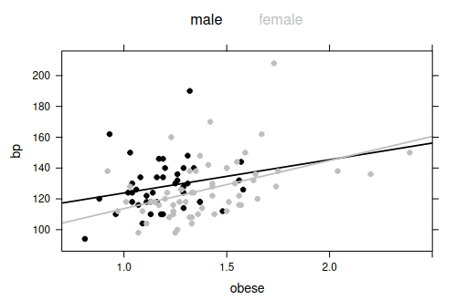

Il seguente plot mette il relazione la variabile obesità con la variabile bp, tenendo conto anche del fattore sesso (che viene riportato attraverso il colore dei punti sul plot).

Si osserva che ai punti si sovrappongono anche due rette di regressione (una per il fattore maschio, una per il fattore femmina). Se si dovesse effettuare qualche considerazione molto generale, si può dire che a colpo d’occhio si nota che:

- tutti i valori più estremi per la variabile obesità sono femmine, mentre per quanto riguarda la variabile bp non ci sono grosse differenze (anche se i maschi tendono ad avere un valore un po’ più elevato)
- la retta di regressione per i maschi mostra come essi tendono - di base - ad avere bp elevata anche a fronte di non obesità; al contrario, la retta relativa alle femmine ha un intercetta più bassa ma anche una pendenza (leggermente) più elevata. Ciò sembra indicare che il fattore obesità sia più rilevante per le femmine
- attenzione però, questa affermazione potrebbe essere affrettata, in quanto nei nostri dati non abbiamo osservazioni relative a maschi fortemente obesi e pertanto non abbiamo una visione completa.

### Analisi preliminare

Partiamo con una panoramica rapida del dataset.

```r
help(bp.obese)
```

| bp.obese | R Documentation |
| --- | --- |

## Obesity and blood pressure

### Description

The `bp.obese` data frame has 102 rows and 3 columns. It contains data from a random sample of Mexican-American adults in a small California town.

### Usage

```r
bp.obese
```

### Format

This data frame contains the following columns:

**`sex`**

a numeric vector code, 0: male, 1: female.

**`obese`**

a numeric vector, ratio of actual weight to ideal weight from New York Metropolitan Life Tables.

**`bp`**

a numeric vector,systolic blood pressure (mm Hg).

### Source

B.W. Brown and M. Hollander (1977), *Statistics: A Biomedical Introduction,* Wiley.

### Examples

```r
plot(bp~obese,pch = ifelse(sex==1, "F", "M"), data = bp.obese)
```

```r
summary(bp.obese)
```

|  | sex | obese | bp |
| --- | --- | --- | --- |
|  | Min. :0.0000 | Min. :0.810 | Min. : 94.0 |
|  | 1st Qu.:0.0000 | 1st Qu.:1.143 | 1st Qu.:116.0 |
|  | Median :1.0000 | Median :1.285 | Median :124.0 |
|  | Mean :0.5686 | Mean :1.313 | Mean :127.0 |
|  | 3rd Qu.:1.0000 | 3rd Qu.:1.430 | 3rd Qu.:137.5 |
|  | Max. :1.0000 | Max. :2.390 | Max. :208.0 |

Il dataset è costituito da tre variabili, due numeriche continue (obese e bp) e una categoriale non ordinale (sex).

Trasformiamo la variabile categoriale in un fattore.

```r
bp.obese2 <- bp.obese
bp.obese2$sex <- factor(bp.obese$sex, labels = c("male", "female"))
summary(bp.obese2)
```

|  | sex | obese | bp |
| --- | --- | --- | --- |
|  | male :44 | Min. :0.810 | Min. : 94.0 |
|  | female:58 | 1st Qu.:1.143 | 1st Qu.:116.0 |
|  | NA | Median :1.285 | Median :124.0 |
|  | NA | Mean :1.313 | Mean :127.0 |
|  | NA | 3rd Qu.:1.430 | 3rd Qu.:137.5 |
|  | NA | Max. :2.390 | Max. :208.0 |

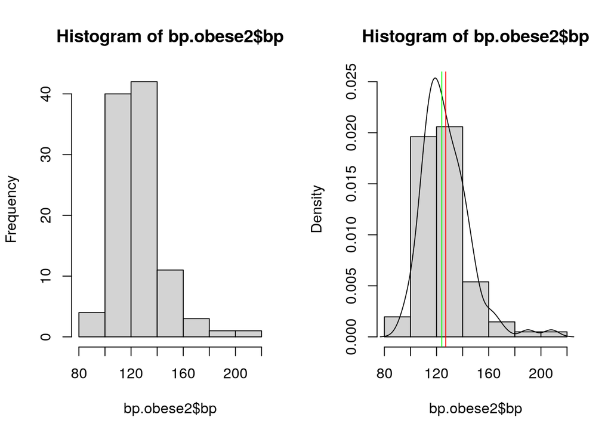

```r
# breaks <- 2 + (0:10) * 0.2
par(mfrow = c(1,2))
hist(bp.obese2$bp) # , breaks = breaks)
hist(bp.obese2$bp, probability = T, ylim=c(0, 0.025)) #, breaks = breaks)
lines(density(bp.obese2$bp))
abline(v=mean(bp.obese2$bp), col="red")
abline(v=median(bp.obese2$bp), col="green")
```

```r
par(mfrow = c(1,1))
```

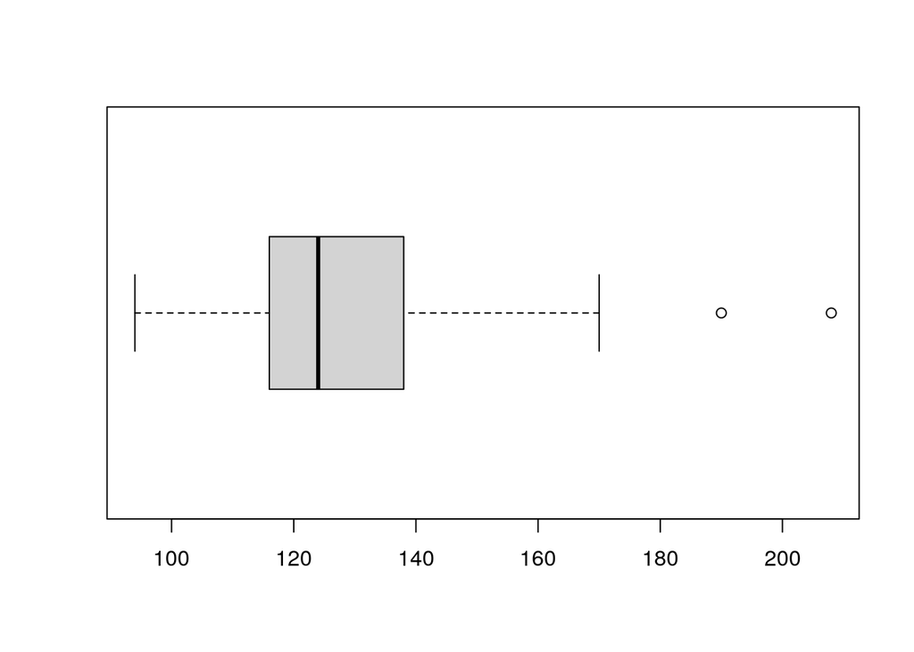

```r
boxplot(bp.obese2$bp, horizontal = T)
```

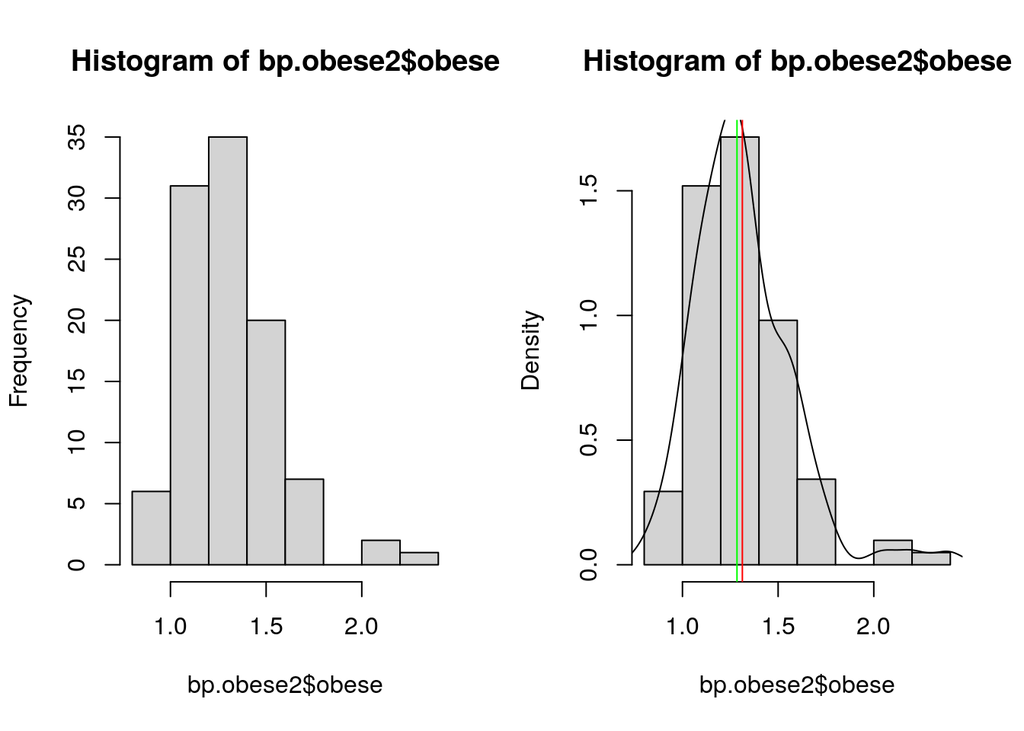

```r
par(mfrow = c(1,2))
hist(bp.obese2$obese) # , breaks = breaks)
hist(bp.obese2$obese, probability = T,) #, breaks = breaks)
lines(density(bp.obese2$obese))
abline(v=mean(bp.obese2$obese), col="red")
abline(v=median(bp.obese2$obese), col="green")
```

```r
par(mfrow = c(1,1))
```

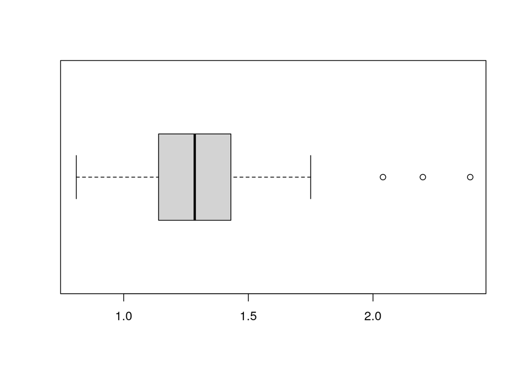

```r
boxplot(bp.obese2$obese, horizontal = T)
```

La variabile obese invece nel suo complesso risulta più simmetrica, se non fosse per pochi outlyer (che tra l’altro, come si è visto dal plot fornito all’inizio sono tutte oss. relative al fattore femmina, pertanto potrebbero portare ad un bias).

```r
library(moments)
skewness(bp.obese2$obese)
```

```
## [1] 1.260221
```

```r
kurtosis(bp.obese2$obese)
```

```
## [1] 6.085016
```

```r
skewness(bp.obese2$bp)
```

```
## [1] 1.406322
```

```r
kurtosis(bp.obese2$bp)
```

```
## [1] 6.740396
```

In entrambi i casi, gli indici riportano un’elevata curtosi (>3, leptocurtosi, la campana risulta stretta) e un’assimetria destra (probabilmente dovuta agli outlyer). Visto che ci interessa la normalità di bp, proviamo a rimuovere gli outlyer

```r
bp.obese3 <- bp.obese2[bp.obese2$bp<=180, ]

summary(bp.obese3$bp)
```

| Min. | 1st Qu. | Median | Mean | 3rd Qu. | Max. |
| --- | --- | --- | --- | --- | --- |
| 94 | 116 | 124 | 125.58 | 136 | 170 |

```r
skewness(bp.obese3$bp)
```

```
## [1] 0.4900074
```

```r
kurtosis(bp.obese3$bp)
```

```
## [1] 3.046533
```

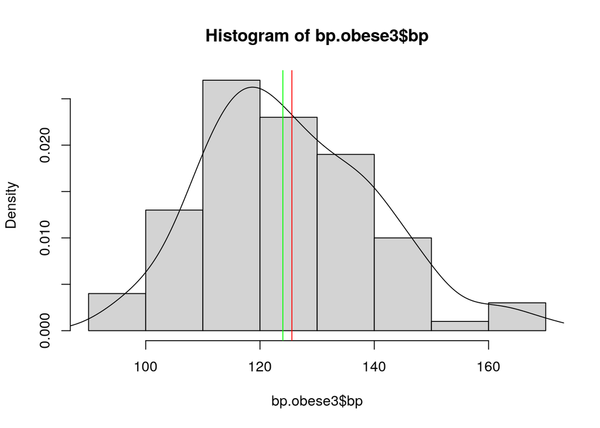

```r
hist(bp.obese3$bp, probability = T) #, breaks = breaks)
lines(density(bp.obese3$bp))
abline(v=mean(bp.obese3$bp), col="red")
abline(v=median(bp.obese3$bp), col="green")
```

Si osserva dagli indici che ciò migliora molto sia l’indice di di simmetria che di curtosi. Per il momento proseguiamo l’analisi con i dati completi, ma teniamo aperta la possibilità di rimuovere gli outlyer se riscontriamo problematiche con il modello.

Infine, per quanto riguarda la variabile sex già dal summary si nota che abbiamo leggermente più osservazioni per il livello femmina.

Proviamo ora a mettere in relazione le tre variabili tra di loro:

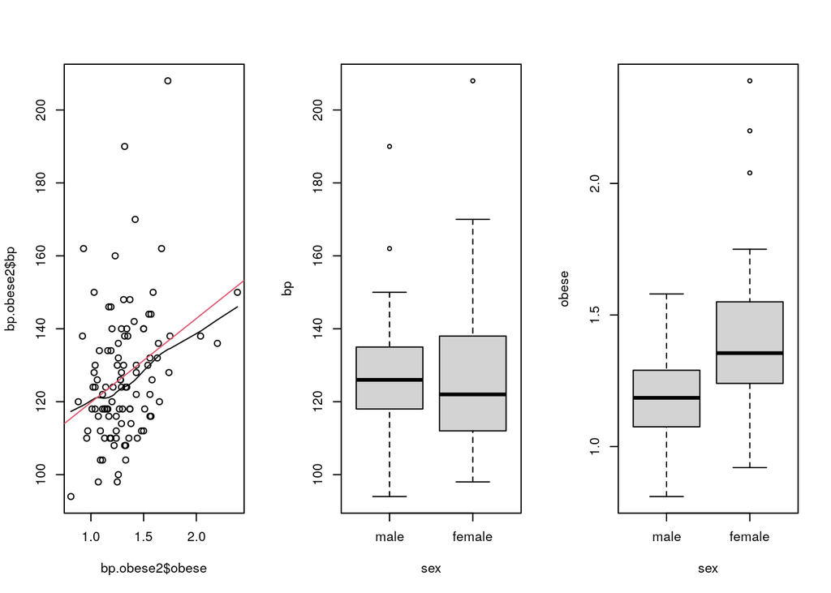

```r
par(mfrow=c(1,3))

plot(bp.obese2$obese, bp.obese2$bp)
lines(lowess(bp.obese2$obese, bp.obese2$bp), col=1)
abline(lm(bp~obese, data = bp.obese2), col=2)

boxplot(bp~sex, data = bp.obese2)

boxplot(obese~sex, data = bp.obese2)
```

```r
par(mfrow=c(1,3))
```

Dal primo grafico, si osserva una vaga correlazione lineare tra obese e bp. Detto ciò, si osserva anche che tale correlazione sembra essere piuttosto debole, vista l’alta variabilità di bp.

```r
cor(bp.obese2$obese, bp.obese2$bp, method = "pearson")
```

```
## [1] 0.3261385
```

Il bassisimo coefficente di correlazione di Pearson sostiene questa teoria.

Per quanto riguarda la relazione tra tra sex e bp, si osserva che:

- i maschi presentano una bp meno variabile rispetto alle femmine

```r
mean(bp.obese2[bp.obese2$sex=="male", "bp"])
```

```
## [1] 127.9545
```

```r
mean(bp.obese2[bp.obese2$sex=="female", "bp"])
```

```
## [1] 126.3103
```

```r
var(bp.obese2[bp.obese2$sex=="male", "bp"])
```

```
## [1] 275.2537
```

```r
var(bp.obese2[bp.obese2$sex=="female", "bp"])
```

```
## [1] 377.095
```

- seppur dal plot iniziale sembra che i valori dei maschi siano più alti di quelli delle femmine, non è così tanto vero (come si può osservare dal boxplot e dalla media)
- i valori estremi riguardano ambo i sessi
- considerazioni simili si possono effettuare anche escludendo gli outlyer più significativi

```r
mean(bp.obese3[bp.obese3$sex=="male", "bp"])
```

```
## [1] 126.5116
```

```r
mean(bp.obese3[bp.obese3$sex=="female", "bp"])
```

```
## [1] 124.8772
```

```r
var(bp.obese3[bp.obese3$sex=="male", "bp"])
```

```
## [1] 188.0177
```

```r
var(bp.obese3[bp.obese3$sex=="female", "bp"])
```

```
## [1] 262.5739
```

Infine, nel dataset preso in esame, le osservazioni con alto indice di obesità tendono ad essere soprattutto donne. E’ bene tenere in considerazione questo fattore per l’analisi formale successiva, onde evitare di creare bias.

After fitting these linear models `fit1 <- lm(bp ∼ obese,data=bp.obese)`, `fit2 <- lm(bp ∼ obese+sex,data=bp.obese)` and `fit3 <- lm(bp ∼ obese*sex,data=bp.obese)`, the following outputs are obtained by the R function summary.

```
##
## Call:
## lm(formula = bp ~ obese, data = bp.obese)
##
## Residuals:
##     Min      1Q  Median      3Q     Max
## -27.570 -11.241  -2.400   9.116  71.390
##
## Coefficients:
##             Estimate Std. Error t value Pr(>|t|)
## (Intercept)   96.818      8.920   10.86  < 2e-16 ***
## obese         23.001      6.667    3.45 0.000822 ***
## ---
## Signif. codes:  0 '***' 0.001 '**' 0.01 '*' 0.05 '.' 0.1 ' ' 1
##
## Residual standard error: 17.28 on 100 degrees of freedom
## Multiple R-squared:  0.1064, Adjusted R-squared:  0.09743
## F-statistic:  11.9 on 1 and 100 DF,  p-value: 0.0008222
```

```
##
## Call:
## lm(formula = bp ~ obese + sex, data = bp.obese)
##
## Residuals:
##     Min      1Q  Median      3Q     Max
## -24.263 -11.613  -2.057   6.424  72.207
##
## Coefficients:
##             Estimate Std. Error t value Pr(>|t|)
## (Intercept)   93.287      8.937  10.438  < 2e-16 ***
## obese         29.038      7.172   4.049 0.000102 ***
## sex           -7.730      3.715  -2.081 0.040053 *
## ---
## Signif. codes:  0 '***' 0.001 '**' 0.01 '*' 0.05 '.' 0.1 ' ' 1
##
## Residual standard error: 17 on 99 degrees of freedom
## Multiple R-squared:  0.1438, Adjusted R-squared:  0.1265
## F-statistic: 8.314 on 2 and 99 DF,  p-value: 0.0004596
```

```
##
## Call:
## lm(formula = bp ~ obese * sex, data = bp.obese)
##
## Residuals:
##     Min      1Q  Median      3Q     Max
## -25.645 -11.621  -1.708   6.737  71.500
##
## Coefficients:
##             Estimate Std. Error t value Pr(>|t|)
## (Intercept)  102.112     18.231   5.601 1.95e-07 ***
## obese         21.646     15.118   1.432    0.155
## sex          -19.596     21.664  -0.905    0.368
## obese:sex      9.558     17.191   0.556    0.579
## ---
## Signif. codes:  0 '***' 0.001 '**' 0.01 '*' 0.05 '.' 0.1 ' ' 1
##
## Residual standard error: 17.05 on 98 degrees of freedom
## Multiple R-squared:  0.1465, Adjusted R-squared:  0.1204
## F-statistic: 5.607 on 3 and 98 DF,  p-value: 0.001368
```

Describe how to interpret these results, and then suggest how to proceed with further analyses.

## Compito del 15 febbraio 2018

Let us consider the dataframe SAheart of the library ElemStatLearn, which comprises information about a retrospective sample of males in a heart-disease high-risk region of the Western Cape, South Africa. The help file and the output of the str command are given below

| SAheart | R Documentation |
| --- | --- |

## South African Hearth Disease Data

### Format

A data frame with 462 observations on the following 10 variables.

**sbp**

systolic blood pressure

**tobacco**

cumulative tobacco (kg)

**ldl**

low density lipoprotein cholesterol

**adiposity**

a numeric vector

**famhist**

family history of heart disease, a factor with levels `Absent` `Present`

**typea**

type-A behavior

**obesity**

a numeric vector

**alcohol**

current alcohol consumption

**age**

age at onset

**chd**

response, coronary heart disease

```
## 'data.frame':    462 obs. of  10 variables:
##  $ sbp      : int  160 144 118 170 134 132 142 114 114 132 ...
##  $ tobacco  : num  12 0.01 0.08 7.5 13.6 6.2 4.05 4.08 0 0 ...
##  $ ldl      : num  5.73 4.41 3.48 6.41 3.5 6.47 3.38 4.59 3.83 5.8 ...
##  $ adiposity: num  23.1 28.6 32.3 38 27.8 ...
##  $ famhist  : Factor w/ 2 levels "Absent","Present": 2 1 2 2 2 2 1 2 2 2 ...
##  $ typea    : int  49 55 52 51 60 62 59 62 49 69 ...
##  $ obesity  : num  25.3 28.9 29.1 32 26 ...
##  $ alcohol  : num  97.2 2.06 3.81 24.26 57.34 ...
##  $ age      : int  52 63 46 58 49 45 38 58 29 53 ...
##  $ chd      : int  1 1 0 1 1 0 0 1 0 1 ...
```

The aim of the study is to analyze the potential relationship between the binary response variable chd and the explanatory variables considered in the dataframe. Describe how to perform a preli- minary data analysis on this dataframe, using suitable R commands, and comment the following plot.

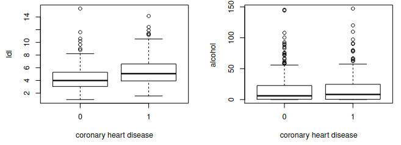

With the command `mod0 <- glm(chd ∼ ldl, data = SAheart, family = binomial)`, a simple logistic regression model is defined for describing the potential effect of the level of ldl on the probability of coronary heart disease. Comment the model fitting outcomes given by the function summary.

```
##
## Call:
## glm(formula = chd ~ ldl, family = binomial, data = SAheart)
##
## Deviance Residuals:
##     Min       1Q   Median       3Q      Max
## -2.1647  -0.8948  -0.7426   1.2688   1.8637
##
## Coefficients:
##             Estimate Std. Error z value Pr(>|z|)
## (Intercept) -1.96867    0.27308  -7.209 5.63e-13 ***
## ldl          0.27466    0.05164   5.319 1.04e-07 ***
## ---
## Signif. codes:  0 '***' 0.001 '**' 0.01 '*' 0.05 '.' 0.1 ' ' 1
##
## (Dispersion parameter for binomial family taken to be 1)
##
##     Null deviance: 596.11  on 461  degrees of freedom
## Residual deviance: 564.28  on 460  degrees of freedom
## AIC: 568.28
##
## Number of Fisher Scoring iterations: 4
```

After fitting these two further logistic regression models `mod1 <- glm(chd ∼ ., data = SAheart, family = binomial)` and `mod2 <- glm(chd ∼ tobacco + ldl + famhist + typea + age + ldl:famhist, data = SAheart, family = binomial)`, the following outputs are obtained by the R function summary.

```
##
## Call:
## glm(formula = chd ~ ., family = binomial, data = SAheart)
##
## Deviance Residuals:
##     Min       1Q   Median       3Q      Max
## -1.7781  -0.8213  -0.4387   0.8889   2.5435
##
## Coefficients:
##                  Estimate Std. Error z value Pr(>|z|)
## (Intercept)    -6.1507209  1.3082600  -4.701 2.58e-06 ***
## sbp             0.0065040  0.0057304   1.135 0.256374
## tobacco         0.0793764  0.0266028   2.984 0.002847 **
## ldl             0.1739239  0.0596617   2.915 0.003555 **
## adiposity       0.0185866  0.0292894   0.635 0.525700
## famhistPresent  0.9253704  0.2278940   4.061 4.90e-05 ***
## typea           0.0395950  0.0123202   3.214 0.001310 **
## obesity        -0.0629099  0.0442477  -1.422 0.155095
## alcohol         0.0001217  0.0044832   0.027 0.978350
## age             0.0452253  0.0121298   3.728 0.000193 ***
## ---
## Signif. codes:  0 '***' 0.001 '**' 0.01 '*' 0.05 '.' 0.1 ' ' 1
##
## (Dispersion parameter for binomial family taken to be 1)
##
##     Null deviance: 596.11  on 461  degrees of freedom
## Residual deviance: 472.14  on 452  degrees of freedom
## AIC: 492.14
##
## Number of Fisher Scoring iterations: 5
```

```
##
## Call:
## glm(formula = chd ~ tobacco + ldl + famhist + typea + age + ldl:famhist,
##     family = binomial, data = SAheart)
##
## Deviance Residuals:
##     Min       1Q   Median       3Q      Max
## -1.8463  -0.7938  -0.4419   0.9161   2.4956
##
## Coefficients:
##                    Estimate Std. Error z value Pr(>|z|)
## (Intercept)        -5.79224    0.94625  -6.121 9.28e-10 ***
## tobacco             0.08496    0.02628   3.233  0.00122 **
## ldl                 0.01758    0.07302   0.241  0.80974
## famhistPresent     -0.77068    0.62341  -1.236  0.21637
## typea               0.03690    0.01240   2.974  0.00294 **
## age                 0.05140    0.01030   4.990 6.03e-07 ***
## ldl:famhistPresent  0.33334    0.11595   2.875  0.00404 **
## ---
## Signif. codes:  0 '***' 0.001 '**' 0.01 '*' 0.05 '.' 0.1 ' ' 1
##
## (Dispersion parameter for binomial family taken to be 1)
##
##     Null deviance: 596.11  on 461  degrees of freedom
## Residual deviance: 466.90  on 455  degrees of freedom
## AIC: 480.9
##
## Number of Fisher Scoring iterations: 5
```

Describe how to interpret these results, and then suggest how to proceed with further analyses.

## Compito del 11 giugno 2018

Let us consider the dataframe `house`, which includes information about the price, the size, the floor, the number of bedrooms (bed) and the number of bathrooms (bath) of 546 houses. The output of the str command is given below

```
## 'data.frame':    546 obs. of  5 variables:
##  $ price: num  42000 38500 49500 60500 61000 66000 66000 69000 83800 88500 ...
##  $ size : int  5850 4000 3060 6650 6360 4160 3880 4160 4800 5500 ...
##  $ bed  : int  3 2 3 3 2 3 3 3 3 3 ...
##  $ bath : int  1 1 1 1 1 1 2 1 1 2 ...
##  $ floor: int  2 1 1 2 1 1 2 3 1 4 ...
```

A suitable linear regression model can be defined in order to study the potential relationship between the price, which is the response variable, and the explanatory variables considered in the dataframe. Describe how to perform a preliminary data analysis on this dataframe, using suitable R commands. Moreover, consider the following plots and discuss the possibility of measuring the variables price and size in the logarithmic scale.

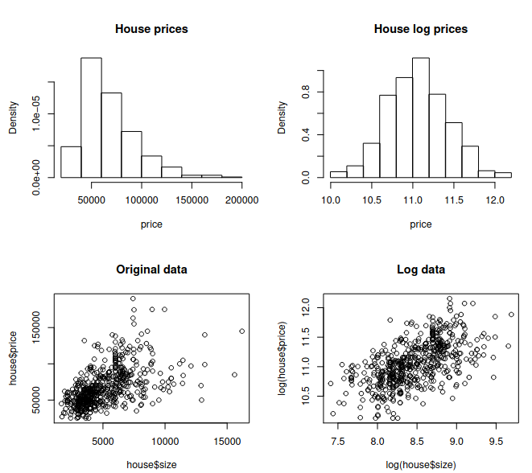

## Compito del 4 febbraio 2019

```
## 'data.frame':    3296 obs. of  5 variables:
##  $ exper : int  9 12 11 9 8 9 8 10 12 7 ...
##  $ male  : Factor w/ 2 levels "0","1": 1 1 1 1 1 1 1 1 1 1 ...
##  $ school: int  13 12 11 14 14 14 12 12 10 12 ...
##  $ wage  : num  6.32 5.48 3.64 4.59 2.42 ...
##  $ region: Factor w/ 3 levels "Center","North",..: 1 1 3 1 1 1 1 1 1 3 ...
```

The aim of the study is to analyze the potential relationship between the response variable wage and the explanatory variables considered in the dataframe. Describe how to perform a preliminary data analysis on this dataframe, using suitable R commands. Moreover, consider the following plots and discuss the possibility of measuring the variable `wage` in the logarithmic scale

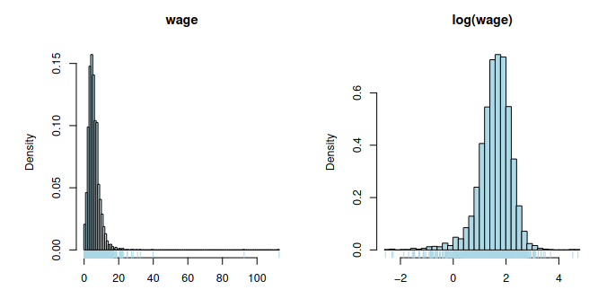

In order to describe the effect of the factor male on the response log(wage) we may analize this plot, where the probability distribution of log(wage) is represented by considering the kernel density estimates conditioned on the two levels (1 male, 0 female) of the variable male

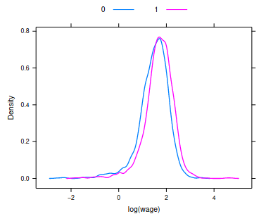

With the commands `mod.0<-lm(log(wage) ∼ male,data=wages)` and `mod.1<-lm(log(wage) ∼ exper*male, data=wages)`, two regression models are defined for describing the potential effect of male and exper on the response log(wage). Comment the model fitting outcomes given by the function summary (Hint: consider the fact that the average years of experience in the sample is lower for women than for men).

```
##
## Call:
## lm(formula = log(wage) ~ male, data = wages)
##
## Residuals:
##     Min      1Q  Median      3Q     Max
## -4.0445 -0.3073  0.0544  0.3839  3.0325
##
## Coefficients:
##             Estimate Std. Error t value Pr(>|t|)
## (Intercept)  1.47475    0.01559   94.59   <2e-16 ***
## male1        0.21826    0.02154   10.13   <2e-16 ***
## ---
## Signif. codes:  0 '***' 0.001 '**' 0.01 '*' 0.05 '.' 0.1 ' ' 1
##
## Residual standard error: 0.6176 on 3294 degrees of freedom
## Multiple R-squared:  0.03023,    Adjusted R-squared:  0.02994
## F-statistic: 102.7 on 1 and 3294 DF,  p-value: < 2.2e-16
```

```
##
## Call:
## lm(formula = log(wage) ~ exper * male, data = wages)
##
## Residuals:
##     Min      1Q  Median      3Q     Max
## -4.0906 -0.3050  0.0560  0.3792  3.0468
##
## Coefficients:
##              Estimate Std. Error t value Pr(>|t|)
## (Intercept)  1.193551   0.057470  20.768  < 2e-16 ***
## exper        0.036367   0.007156   5.082 3.94e-07 ***
## male1        0.463707   0.079062   5.865 4.93e-09 ***
## exper:male1 -0.032071   0.009518  -3.369 0.000762 ***
## ---
## Signif. codes:  0 '***' 0.001 '**' 0.01 '*' 0.05 '.' 0.1 ' ' 1
##
## Residual standard error: 0.6153 on 3292 degrees of freedom
## Multiple R-squared:  0.03792,    Adjusted R-squared:  0.03704
## F-statistic: 43.25 on 3 and 3292 DF,  p-value: < 2.2e-16
```

Finally, a complete regression model is fitted `mod.2 <- lm(log(wage) ∼., data=wages)` and the following output is obtained by the R function summary.

```
##
## Call:
## lm(formula = log(wage) ~ ., data = wages)
##
## Residuals:
##     Min      1Q  Median      3Q     Max
## -4.0008 -0.2821  0.0468  0.3673  3.2337
##
## Coefficients:
##              Estimate Std. Error t value Pr(>|t|)
## (Intercept) -0.279709   0.090321  -3.097  0.00197 **
## exper        0.034618   0.004549   7.610 3.55e-14 ***
## male1        0.246474   0.020607  11.961  < 2e-16 ***
## school       0.122909   0.006278  19.578  < 2e-16 ***
## regionNorth  0.051107   0.024505   2.086  0.03709 *
## regionSouth  0.047168   0.024969   1.889  0.05898 .
## ---
## Signif. codes:  0 '***' 0.001 '**' 0.01 '*' 0.05 '.' 0.1 ' ' 1
##
## Residual standard error: 0.5831 on 3290 degrees of freedom
## Multiple R-squared:  0.1364, Adjusted R-squared:  0.1351
## F-statistic: 103.9 on 5 and 3290 DF,  p-value: < 2.2e-16
```

Describe how to interpret these results, and then suggest how to proceed with further analyses.

## Compito del 21 febbraio 2019

```
## 'data.frame':    42535 obs. of  5 variables:
##  $ good     : Factor w/ 2 levels "bad","good": 2 1 2 2 2 2 2 2 1 1 ...
##  $ purpose  : Factor w/ 8 levels "debt_consolidation",..: 1 4 7 6 6 8 1 4 7 6 ...
##  $ fico     : int  737 742 737 692 697 732 692 662 677 727 ...
##  $ loan_amnt: int  5000 2500 2400 10000 3000 5000 7000 3000 5600 5375 ...
##  $ income   : num  24000 30000 NA 49200 80000 36000 NA 48000 40000 15000 ...
```

Moreover, the output of the command summary is also given

|  | good | purpose | fico | loan_amnt | income |
| --- | --- | --- | --- | --- | --- |
|  | bad : 6371 | debt_consolidation:25253 | Min. :612.0 | Min. : 500 | Min. : 4800 |
|  | good:36164 | other : 5160 | 1st Qu.:687.0 | 1st Qu.: 5200 | 1st Qu.: 44995 |
|  | NA | major_purchase : 3926 | Median :712.0 | Median : 9700 | Median : 63000 |
|  | NA | home_improvement : 3625 | Mean :715.1 | Mean :11090 | Mean : 75186 |
|  | NA | small_business : 1992 | 3rd Qu.:742.0 | 3rd Qu.:15000 | 3rd Qu.: 90000 |
|  | NA | vacation_wedding : 1404 | Max. :827.0 | Max. :35000 | Max. :6000000 |
|  | NA | (Other) : 1175 | NA | NA | NA’s :18758 |

The aim of the study is to analyze the potential relationship between the response variable good and the explanatory variables considered in the data frame, in order to evaluate the possible good/bad behaviour of a customer. Describe how to perform a preliminary data analysis on this data frame, using suitable R commands. Moreover, consider and discuss the following plots

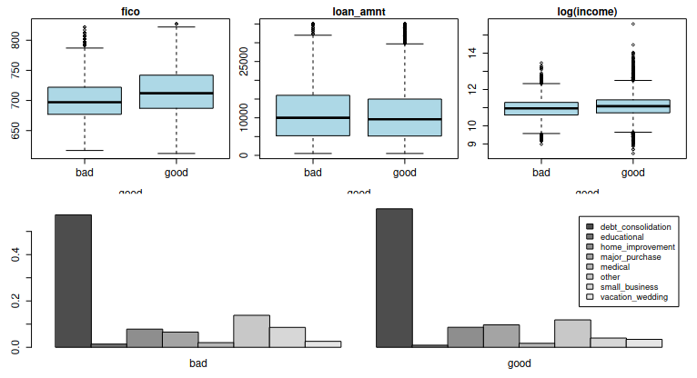

In order to describe the effect of the factor fico on the response good we consider a simple logistic regression model fitted using the command `mod.1<-glm(good ∼ fico, data = loan, family = "binomial")`. Comment the model fitting outcomes given by the function summary and the output given by the subsequent commands.

```r
mod.1 <- glm(good ~ fico, data = loan, family = "binomial")
summary(mod.1)
```

```
##
## Call:
## glm(formula = good ~ fico, family = "binomial", data = loan)
##
## Deviance Residuals:
##     Min       1Q   Median       3Q      Max
## -2.5172   0.4078   0.5306   0.6294   0.9622
##
## Coefficients:
##              Estimate Std. Error z value Pr(>|z|)
## (Intercept) -7.033068   0.296922  -23.69   <2e-16 ***
## fico         0.012358   0.000421   29.35   <2e-16 ***
## ---
## Signif. codes:  0 '***' 0.001 '**' 0.01 '*' 0.05 '.' 0.1 ' ' 1
##
## (Dispersion parameter for binomial family taken to be 1)
##
##     Null deviance: 35928  on 42534  degrees of freedom
## Residual deviance: 34985  on 42533  degrees of freedom
## AIC: 34989
##
## Number of Fisher Scoring iterations: 5
```

```r
exp(coef(mod.1))
```

```
##  (Intercept)         fico
## 0.0008822209 1.0124345145
```

```r
test <- data.frame(fico=c(700,750))
test$pred <- predict(mod.1,test, type="response")
test
```

| fico | pred |
| --- | --- |
| 700 | 0.8344391 |
| 750 | 0.9033761 |

Two further logistic regression models are fitted using `mod.2<-glm(good ∼ fico + loan_amnt, data = loan, family = "binomial")` and `mod.3<-glm(good ∼ fico + loan_amnt + income + purpose, data = loan, family = "binomial")`. Comment the corresponding output obtained by the R function summary and then suggest how to proceed with a further predictive analysis.

```
##
## Call:
## glm(formula = good ~ fico + loan_amnt, family = "binomial", data = loan)
##
## Deviance Residuals:
##     Min       1Q   Median       3Q      Max
## -2.6261   0.4011   0.5256   0.6261   0.9423
##
## Coefficients:
##               Estimate Std. Error z value Pr(>|z|)
## (Intercept) -7.367e+00  3.007e-01  -24.50   <2e-16 ***
## fico         1.319e-02  4.306e-04   30.62   <2e-16 ***
## loan_amnt   -2.229e-05  1.815e-06  -12.28   <2e-16 ***
## ---
## Signif. codes:  0 '***' 0.001 '**' 0.01 '*' 0.05 '.' 0.1 ' ' 1
##
## (Dispersion parameter for binomial family taken to be 1)
##
##     Null deviance: 35928  on 42534  degrees of freedom
## Residual deviance: 34838  on 42532  degrees of freedom
## AIC: 34844
##
## Number of Fisher Scoring iterations: 5
```

```
##
## Call:
## glm(formula = good ~ fico + loan_amnt + income + purpose, family = "binomial",
##     data = loan)
##
## Deviance Residuals:
##     Min       1Q   Median       3Q      Max
## -3.3659   0.3840   0.5224   0.6320   1.2589
##
## Coefficients:
##                           Estimate Std. Error z value Pr(>|z|)
## (Intercept)             -7.482e+00  4.119e-01 -18.165  < 2e-16 ***
## fico                     1.303e-02  5.906e-04  22.061  < 2e-16 ***
## loan_amnt               -3.663e-05  2.580e-06 -14.200  < 2e-16 ***
## income                   7.203e-06  5.426e-07  13.275  < 2e-16 ***
## purposeeducational      -5.076e-01  2.309e-01  -2.198   0.0279 *
## purposehome_improvement -1.077e-01  7.108e-02  -1.515   0.1298
## purposemajor_purchase    1.388e-02  7.689e-02   0.180   0.8568
## purposemedical          -2.678e-01  1.426e-01  -1.878   0.0604 .
## purposeother            -2.988e-01  6.034e-02  -4.952 7.34e-07 ***
## purposesmall_business   -9.158e-01  7.016e-02 -13.052  < 2e-16 ***
## purposevacation_wedding  1.114e-01  1.126e-01   0.989   0.3226
## ---
## Signif. codes:  0 '***' 0.001 '**' 0.01 '*' 0.05 '.' 0.1 ' ' 1
##
## (Dispersion parameter for binomial family taken to be 1)
##
##     Null deviance: 20592  on 23776  degrees of freedom
## Residual deviance: 19677  on 23766  degrees of freedom
##   (18758 observations deleted due to missingness)
## AIC: 19699
##
## Number of Fisher Scoring iterations: 5
```

## Compito del 28 gennaio 2020

Let us consider the dataframe birthwt, which contains data on 189 births at the Baystate Medical Centre, Springfield, Massachusetts during 1986. The focus is on the variables listed below

| birthwt | R Documentation |
| --- | --- |

## Risk Factors Associated with Low Infant Birth Weight

### Format

This data frame contains the following columns:

**`low`**

indicator of birth weight less than 2.5 kg.

**`age`**

mother’s age in years.

**`lwt`**

mother’s weight in pounds at last menstrual period.

**`race`**

mother’s race (`1` = white, `2` = black, `3` = other).

**`smoke`**

smoking status during pregnancy.

**`ptl`**

number of previous premature labours.

**`ht`**

history of hypertension.

**`ui`**

presence of uterine irritability.

**`ftv`**

number of physician visits during the first trimester.

**`bwt`**

birth weight in grams.

The aim of the study is to analyze the potential relationship between the response variable bwt and the explanatory variables age and race. Describe how to perform a preliminary data analysis on this dataframe using suitable R commands and comment the following plots

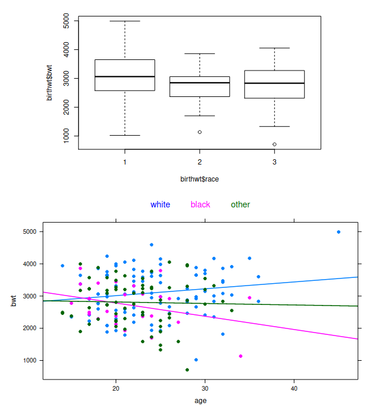

In order to describe the potential relationship between birth weight and age, taking into account also the factor race, we compare the following nested models

```r
bwt.lm1 <- lm(bwt ~ 1 , data = birthwt)
bwt.lm2 <- lm(bwt ~ age, data = birthwt)
bwt.lm3 <- lm(bwt ~ race + age, data = birthwt)
bwt.lm4 <- lm(bwt ~ race*age, data = birthwt)
```

Describe the four models and comment the results given by the Analysis of Variance Table, reported below. Moreover, propose some alternative model selection procedures.

```r
anova(bwt.lm1, bwt.lm2, bwt.lm3, bwt.lm4)
```

| Res.Df | RSS | Df | Sum of Sq | F | Pr(>F) |
| --- | --- | --- | --- | --- | --- |
| 188 | 99969656 | NA | NA | NA | NA |
| 187 | 99154173 | 1 | 815483.2 | 1.590830 | 0.2087958 |
| 186 | 95848562 | 1 | 3305610.3 | 6.448524 | 0.0119274 |
| 185 | 94833785 | 1 | 1014776.9 | 1.979608 | 0.1611095 |

Let us consider Model 3 and comment the output obtained by the R functions summary and plot.

```
##
## Call:
## lm(formula = bwt ~ race + age, data = birthwt)
##
## Residuals:
##     Min      1Q  Median      3Q     Max
## -2104.8  -485.7    11.3   536.0  1746.4
##
## Coefficients:
##             Estimate Std. Error t value Pr(>|t|)
## (Intercept) 3028.482    277.679  10.906   <2e-16 ***
## race        -146.597     57.881  -2.533   0.0121 *
## age            8.039     10.032   0.801   0.4240
## ---
## Signif. codes:  0 '***' 0.001 '**' 0.01 '*' 0.05 '.' 0.1 ' ' 1
##
## Residual standard error: 717.9 on 186 degrees of freedom
## Multiple R-squared:  0.04122,    Adjusted R-squared:  0.03091
## F-statistic: 3.999 on 2 and 186 DF,  p-value: 0.01994
```

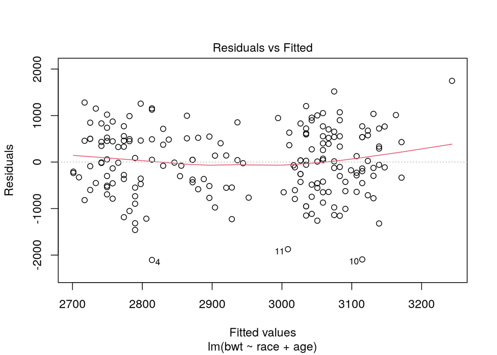

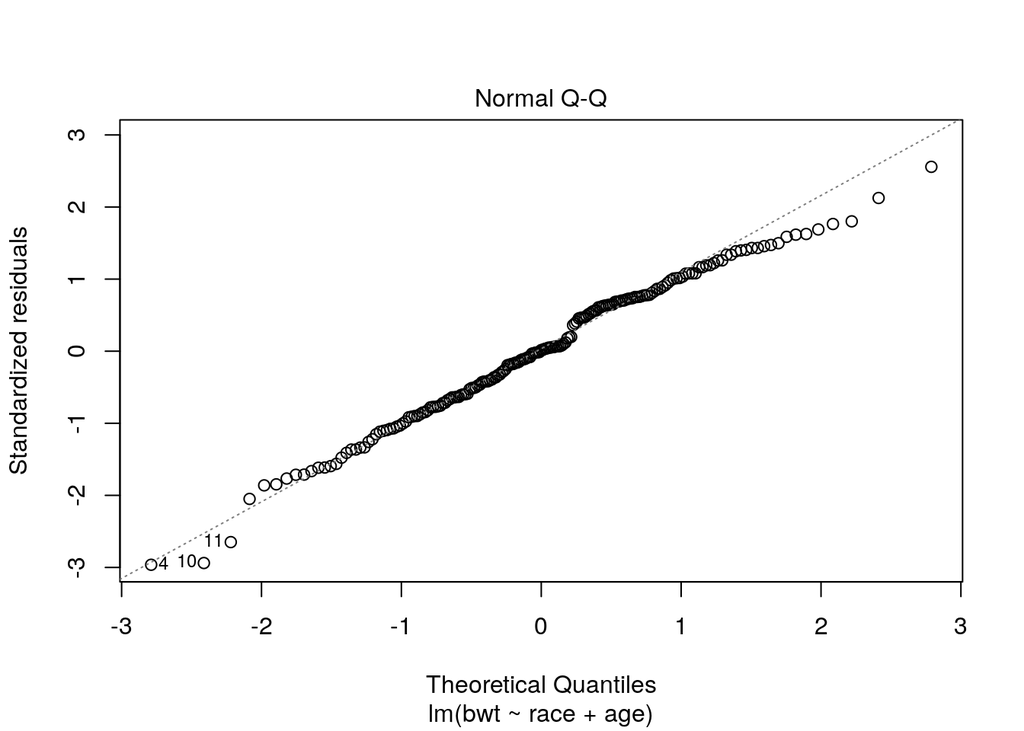

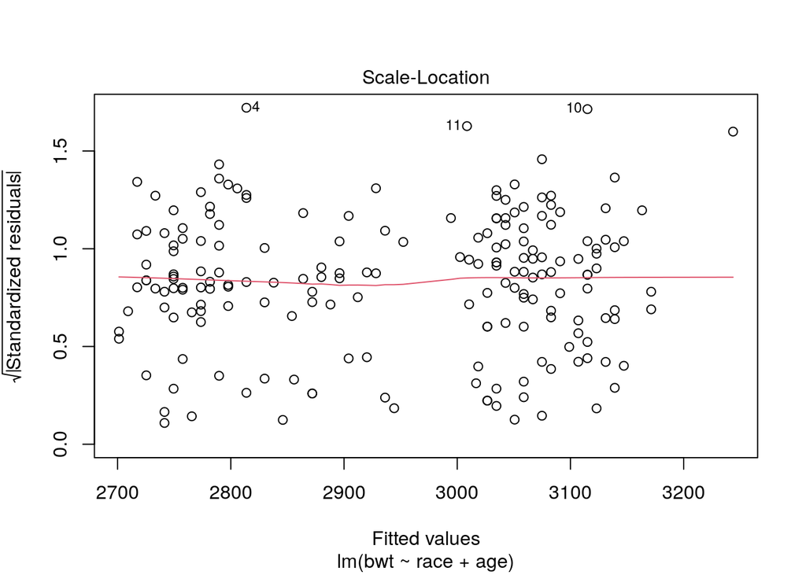

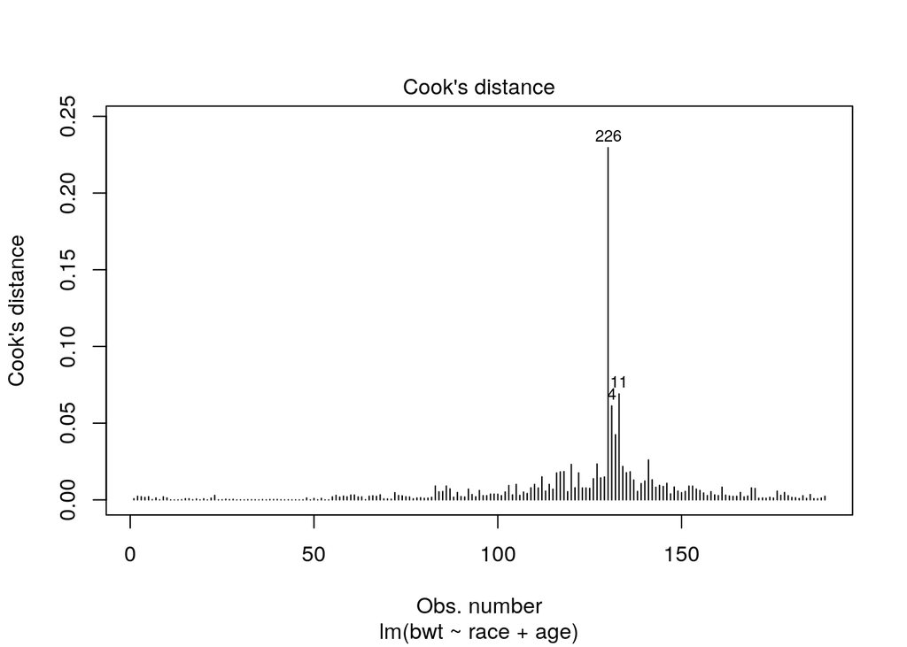

Finally, discuss the following graphical output and then suggest how to proceed with further analyses.

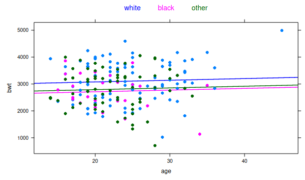

## Compito del 18 febbraio 2020

Let us consider the dataframe wine, which contains information about 178 samples of wines grown in the same region in Italy. The cultivar of each wine sample is observed (variable cultivar, with labels 1, 2, 3), together with the concentration of the 13 different chemicals (variables V1-V13). Describe how to perform a preliminary data analysis on this dataframe using suitable R commands and comment the following outputs.

```r
wine <- read.table("./data/wine.txt", header = TRUE)
summary(wine)
```

|  | V1 | V2 | V3 | V4 | V5 | V6 | V7 | V8 | V9 | V10 | V11 | V12 | V13 | V14 |
| --- | --- | --- | --- | --- | --- | --- | --- | --- | --- | --- | --- | --- | --- | --- |
|  | Min. :1.000 | Min. :11.03 | Min. :0.740 | Min. :1.360 | Min. :10.60 | Min. : 70.00 | Min. :0.980 | Min. :0.340 | Min. :0.1300 | Min. :0.410 | Min. : 1.280 | Min. :0.4800 | Min. :1.270 | Min. : 278.0 |
|  | 1st Qu.:1.000 | 1st Qu.:12.36 | 1st Qu.:1.603 | 1st Qu.:2.210 | 1st Qu.:17.20 | 1st Qu.: 88.00 | 1st Qu.:1.742 | 1st Qu.:1.205 | 1st Qu.:0.2700 | 1st Qu.:1.250 | 1st Qu.: 3.220 | 1st Qu.:0.7825 | 1st Qu.:1.938 | 1st Qu.: 500.5 |
|  | Median :2.000 | Median :13.05 | Median :1.865 | Median :2.360 | Median :19.50 | Median : 98.00 | Median :2.355 | Median :2.135 | Median :0.3400 | Median :1.555 | Median : 4.690 | Median :0.9650 | Median :2.780 | Median : 673.5 |
|  | Mean :1.938 | Mean :13.00 | Mean :2.336 | Mean :2.367 | Mean :19.49 | Mean : 99.74 | Mean :2.295 | Mean :2.029 | Mean :0.3619 | Mean :1.591 | Mean : 5.058 | Mean :0.9574 | Mean :2.612 | Mean : 746.9 |
|  | 3rd Qu.:3.000 | 3rd Qu.:13.68 | 3rd Qu.:3.083 | 3rd Qu.:2.558 | 3rd Qu.:21.50 | 3rd Qu.:107.00 | 3rd Qu.:2.800 | 3rd Qu.:2.875 | 3rd Qu.:0.4375 | 3rd Qu.:1.950 | 3rd Qu.: 6.200 | 3rd Qu.:1.1200 | 3rd Qu.:3.170 | 3rd Qu.: 985.0 |
|  | Max. :3.000 | Max. :14.83 | Max. :5.800 | Max. :3.230 | Max. :30.00 | Max. :162.00 | Max. :3.880 | Max. :5.080 | Max. :0.6600 | Max. :3.580 | Max. :13.000 | Max. :1.7100 | Max. :4.000 | Max. :1680.0 |

```r
sapply(wine[2:14],sd)
```

```
##          V2          V3          V4          V5          V6          V7
##   0.8118265   1.1171461   0.2743440   3.3395638  14.2824835   0.6258510
##          V8          V9         V10         V11         V12         V13
##   0.9988587   0.1244533   0.5723589   2.3182859   0.2285716   0.7099904
##         V14
## 314.9074743
```

Moreover, discuss the results given by the scatterplot matrix considered below, which considers the first 5 numerical variables, with colours indicating cultivar 1 (black), cultivar 2 (red) and cultivar 3 (blue).

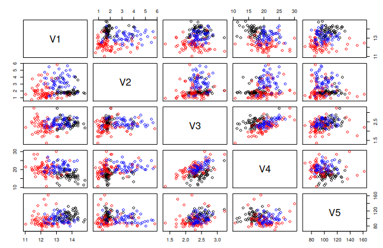

The aim of the study is to adequately synthesize the information given by the original variables V1-V13, in order to capture as much of the information as possible. A further objective is to use some of these new derived variable for distinguishing the three different cultivars. The Principal Components Analysis procedure is applied. Present the main features of this stati- stical procedure, describe the arguments specified below in the function princomp and discuss the output of the function loadings.

```r
wine.pca <- princomp(wine[2:14], cor=TRUE)
loadings(wine.pca)[,1:4]
```

|  | Comp.1 | Comp.2 | Comp.3 | Comp.4 |
| --- | --- | --- | --- | --- |
| V2 | 0.1443294 | 0.4836515 | 0.2073826 | 0.0178563 |
| V3 | -0.2451876 | 0.2249309 | -0.0890129 | -0.5368903 |
| V4 | -0.0020511 | 0.3160688 | -0.6262239 | 0.2141756 |
| V5 | -0.2393204 | -0.0105905 | -0.6120803 | -0.0608594 |
| V6 | 0.1419920 | 0.2996340 | -0.1307569 | 0.3517966 |
| V7 | 0.3946608 | 0.0650395 | -0.1461790 | -0.1980683 |
| V8 | 0.4229343 | -0.0033598 | -0.1506819 | -0.1522948 |
| V9 | -0.2985331 | 0.0287795 | -0.1703682 | 0.2033010 |
| V10 | 0.3134295 | 0.0393017 | -0.1494543 | -0.3990565 |
| V11 | -0.0886167 | 0.5299957 | 0.1373062 | -0.0659257 |
| V12 | 0.2967146 | -0.2792351 | -0.0852219 | 0.4277714 |
| V13 | 0.3761674 | -0.1644962 | -0.1660046 | -0.1841207 |
| V14 | 0.2867522 | 0.3649028 | 0.1267459 | 0.2320709 |

Moreover, discuss the following graphical outputs

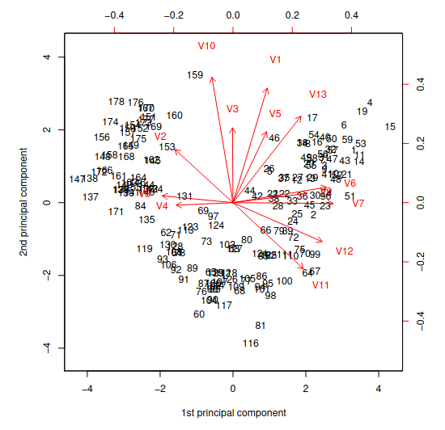

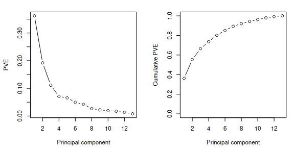

Finally, comment this last plot, with particular concern to the aim of characterizing the three different cultivars.

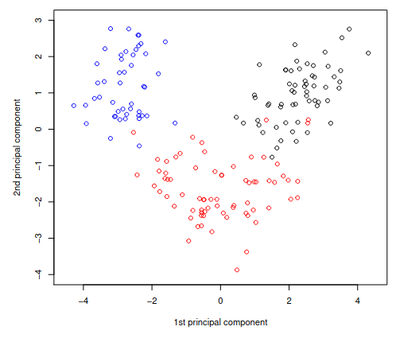